# Predicting exercise pattern from accelerometers data

Timur Akhmedzhanov

November 13, 2016

### In this project, I use the data from accelerometers on the belt, forearm, arm, and dumbell of 6 people in order to predict the manner in which they exerice. Namely, data is split in training and test sets. The data is presprocessed, a few different models are trained on a train set with cross validation, the best model is chosen and used on the test set.

## Reading and preprocessing data.

Both training and testing sets are read and preprocessed - the NA and empty variables are removed. A head function and one explatory plot are used for basic explaratory analysis. As it follows from the names of columns, columns 1 and 3 to 7 should be excluded, since they contain information about measurement number, time and window number rather than physical data.

The variables (except the “classe” which is being predicted) could be scaled and centered for training stage. However, it is not required since accuracy rate of almost 100% is achieved by random forest without it (see next section for details).

```r
set.seed(7)
setwd("C:/Users/Timur/Documents")
training <- read.csv('training.csv')
testing <- read.csv('testing.csv')
dim(training)
```

```
## [1] 19622   160
```

```r
xNA <- colSums(is.na(training))<1
training <- training[,xNA]
xEmpty <- colSums(training == '')<1
training <- training[,xEmpty]
xNol <- colSums(training == '#DIV/0!')<1
training <- training[,xNol]
testing <- testing[,xNA]
testing <- testing[,xEmpty]
testing <- testing[,xNol]
head(testing, n = 1)
```

```
##   X user_name raw_timestamp_part_1 raw_timestamp_part_2   cvtd_timestamp
## 1 1     pedro           1323095002               868349 05/12/2011 14:23
##   new_window num_window roll_belt pitch_belt yaw_belt total_accel_belt
## 1         no         74       123         27    -4.75               20
##   gyros_belt_x gyros_belt_y gyros_belt_z accel_belt_x accel_belt_y
## 1         -0.5        -0.02        -0.46          -38           69
##   accel_belt_z magnet_belt_x magnet_belt_y magnet_belt_z roll_arm
## 1         -179           -13           581          -382     40.7
##   pitch_arm yaw_arm total_accel_arm gyros_arm_x gyros_arm_y gyros_arm_z
## 1     -27.8     178              10       -1.65        0.48       -0.18
##   accel_arm_x accel_arm_y accel_arm_z magnet_arm_x magnet_arm_y
## 1          16          38          93         -326          385
##   magnet_arm_z roll_dumbbell pitch_dumbbell yaw_dumbbell
## 1          481     -17.73748       24.96085      126.236
##   total_accel_dumbbell gyros_dumbbell_x gyros_dumbbell_y gyros_dumbbell_z
## 1                    9             0.64             0.06            -0.61
##   accel_dumbbell_x accel_dumbbell_y accel_dumbbell_z magnet_dumbbell_x
## 1               21              -15               81               523
##   magnet_dumbbell_y magnet_dumbbell_z roll_forearm pitch_forearm
## 1              -528               -56          141          49.3
##   yaw_forearm total_accel_forearm gyros_forearm_x gyros_forearm_y
## 1         156                  33            0.74           -3.34
##   gyros_forearm_z accel_forearm_x accel_forearm_y accel_forearm_z
## 1           -0.59            -110             267            -149
##   magnet_forearm_x magnet_forearm_y magnet_forearm_z problem_id
## 1             -714              419              617          1
```

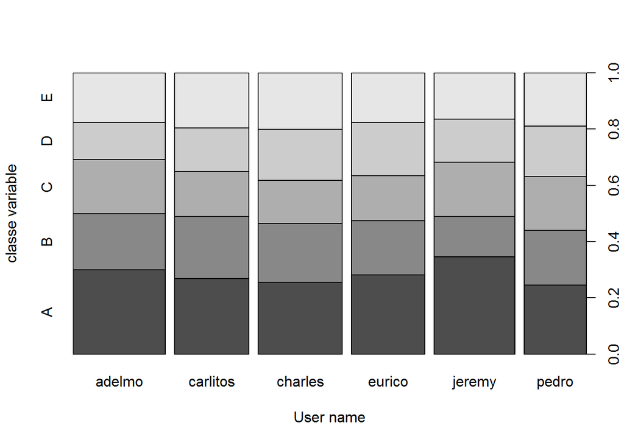

```r
plot(training$user_name,as.factor(training$classe), xlab = 'User name', ylab = 'classe variable')
library(caret)
```

```r
training <- training[,c(2,8:60)]
testing <- testing[,c(2,8:60)]
#training[,-60] <- predict(preProcess(training[,-60], method=c("scale","center")),training[,-60])
#testing[,-60] <- predict(preProcess(testing[,-60], method=c("scale","center")),testing[,-60])
```

## Training models and choosing the best one.

```r
control <- trainControl(method="repeatedcv", number=5, repeats=1)
# train the model
fitRF <- train(classe~., data=training,method="rf", trControl=control)
fitGBM <- train(classe~., data=training, method="gbm", trControl=control, verbose=FALSE)
fitGLM <- train(classe~., data=training,method="glmnet", trControl=control)
prRF <- predict(fitRF, training[,-54])
confusionMatrix(training[,54],prRF)
```

```
## Confusion Matrix and Statistics
##
##           Reference
## Prediction    A    B    C    D    E
##          A 5580    0    0    0    0
##          B    0 3797    0    0    0
##          C    0    0 3422    0    0
##          D    0    0    0 3216    0
##          E    0    0    0    0 3607
##
## Overall Statistics
##
##                Accuracy : 1
##                  95% CI : (0.9998, 1)
##     No Information Rate : 0.2844
##     P-Value [Acc > NIR] : < 2.2e-16
##
##                   Kappa : 1
##  Mcnemar's Test P-Value : NA
##
## Statistics by Class:
##
##                      Class: A Class: B Class: C Class: D Class: E
## Sensitivity            1.0000   1.0000   1.0000   1.0000   1.0000
## Specificity            1.0000   1.0000   1.0000   1.0000   1.0000
## Pos Pred Value         1.0000   1.0000   1.0000   1.0000   1.0000
## Neg Pred Value         1.0000   1.0000   1.0000   1.0000   1.0000
## Prevalence             0.2844   0.1935   0.1744   0.1639   0.1838
## Detection Rate         0.2844   0.1935   0.1744   0.1639   0.1838
## Detection Prevalence   0.2844   0.1935   0.1744   0.1639   0.1838
## Balanced Accuracy      1.0000   1.0000   1.0000   1.0000   1.0000
```

```r
prGBM <- predict(fitGBM, training[,-54])
confusionMatrix(training[,54],prGBM)
```

```
## Confusion Matrix and Statistics
##
##           Reference
## Prediction    A    B    C    D    E
##          A 5524   37   11    6    2
##          B   99 3627   71    0    0
##          C    0   79 3300   38    5
##          D    3    5  101 3093   14
##          E    6   20   24   37 3520
##
## Overall Statistics
##
##                Accuracy : 0.9716
##                  95% CI : (0.9691, 0.9738)
##     No Information Rate : 0.287
##     P-Value [Acc > NIR] : < 2.2e-16
##
##                   Kappa : 0.964
##  Mcnemar's Test P-Value : < 2.2e-16
##
## Statistics by Class:
##
##                      Class: A Class: B Class: C Class: D Class: E
## Sensitivity            0.9808   0.9626   0.9410   0.9745   0.9941
## Specificity            0.9960   0.9893   0.9924   0.9925   0.9946
## Pos Pred Value         0.9900   0.9552   0.9643   0.9618   0.9759
## Neg Pred Value         0.9923   0.9911   0.9872   0.9951   0.9987
## Prevalence             0.2870   0.1920   0.1787   0.1618   0.1805
## Detection Rate         0.2815   0.1848   0.1682   0.1576   0.1794
## Detection Prevalence   0.2844   0.1935   0.1744   0.1639   0.1838
## Balanced Accuracy      0.9884   0.9759   0.9667   0.9835   0.9943
```

```r
prGLM <- predict(fitGLM, training[,-54])
confusionMatrix(training[,54],prGLM)
```

```
## Confusion Matrix and Statistics
##
##           Reference
## Prediction    A    B    C    D    E
##          A 4889  170  266  239   16
##          B  518 2553  332  110  284
##          C  345  278 2479  196  124
##          D  220  132  361 2398  105
##          E  118  386  164  233 2706
##
## Overall Statistics
##
##                Accuracy : 0.7657
##                  95% CI : (0.7597, 0.7716)
##     No Information Rate : 0.3104
##     P-Value [Acc > NIR] : < 2.2e-16
##
##                   Kappa : 0.7028
##  Mcnemar's Test P-Value : < 2.2e-16
##
## Statistics by Class:
##
##                      Class: A Class: B Class: C Class: D Class: E
## Sensitivity            0.8028   0.7255   0.6882   0.7550   0.8365
## Specificity            0.9489   0.9227   0.9411   0.9503   0.9450
## Pos Pred Value         0.8762   0.6724   0.7244   0.7456   0.7502
## Neg Pred Value         0.9145   0.9390   0.9307   0.9526   0.9670
## Prevalence             0.3104   0.1793   0.1836   0.1619   0.1649
## Detection Rate         0.2492   0.1301   0.1263   0.1222   0.1379
## Detection Prevalence   0.2844   0.1935   0.1744   0.1639   0.1838
## Balanced Accuracy      0.8759   0.8241   0.8147   0.8526   0.8907
```

## Predicting on a test set.

The chosen model - random forest is applied to the test set. As it can be seen from typing those answers in the quiz for Week 4 of the class, it gives correct prediction in all the cases, which is reasonably close (and equal) to the accuracy of prediction on a training set. It seems that this accuracy was achived due to reasonably small number of possible outcomes and a big number of variables to make prediction from. A large number of samples in training set also helped.

```r
prTest <- predict(fitRF, testing[,-54])
prTest
```

```
##  [1] B A B A A E D B A A B C B A E E A B B B
## Levels: A B C D E
```